# Lab: Introduction to R and RStudio

## Introduction

The goal of this lab is to introduce you to R and RStudio, which you’ll be using throughout the course both to learn the statistical concepts discussed in the textbook and also to analyze real data and come to informed conclusions. To straighten out which is which:

- `R`: is a programming language specfically designed for statistical analysis. `R` is open-source, and is developed by a team of statisticians and programmers in both academia and industry. It is updated frequently and has become the de facto industry standard. In the data science realm, alternatives to `R` include `Python` with the Pandas library, and `Julia`. In the statistics realm, alternatives include SAS, Stata, and SPSS.
- RStudio: is an Integrated Development Environment (IDE) for `R`. RStudio is also open-source software, and depends upon a valid `R` installation to function. RStudio as available as both a both Desktop and Server application. Before RStudio, people used `R` through the command line directly, or through graphical user interfaces like Rcmdr, but RStudio is so vastly superior that these alternatives have few users left. RStudio employees are important drivers of R innovation, and currently maintain the `rmarkdown`, `knitr`, and `dplyr` packages, among others.
- RMarkdown: is a syntax for composing relatively simple documents that combine `R` code and text. R Markdown is an extension of markdown (a general-purpose authoring format) that provides functionality for processing R code and output.

If you are using RStudio Cloud, you should be all set (although please let me know if your account does not work), but if you want to work locally on your computer, you need to install both R and RStudio. - Download and install [RStudio Desktop](http://www.rstudio.com/products/rstudio/) - Download and install [R](http://cran.us.r-project.org/)

As the labs progress, you are encouraged to explore beyond what the labs dictate; a willingness to experiment will make you a much better programmer. Before we get to that stage, however, you need to build some basic fluency in R. Today we begin with the fundamental building blocks of R and RStudio: the interface, reading in data, and basic commands.

The panel in the upper right contains your *environment* as well as a history of the commands that you’ve previously entered. Any plots that you generate will show up in the panel in the lower right corner.

The panel on the left is where the action happens. It’s called the *console*. Everytime you launch RStudio, it will have the same text at the top of the console telling you the version of R that you’re running. Below that information is the *prompt*. As its name suggests, this prompt is really a request, a request for a command. Initially, interacting with R is all about typing commands and interpreting the output. These commands and their syntax have evolved over decades (literally) and now provide what many users feel is a fairly natural way to access data and organize, describe, and invoke statistical computations.

To get you started, enter all commands at the R prompt (i.e. right after `>` on the console); you can either type them in manually or copy and paste them from this document.

R has a number of additional packages that help you perform specific tasks. For example,`dplyr` is an R package designed to simplify the process of data wrangling, and `ggplot2` is for data visualization based on the Grammer of Graphics (a famous book).

In order to use a packages, they must be installed (you only have to do this once, and I’ve done it already for you with many packages) and loaded (you have to do this every time you start an R session).

If you have not installed the packages already (particularly if you are running R and RStudio on your local machine), run the commands below. It may take a few minutes; you’ll know when the packages have finished installing when you see the R prompt (`>`) return in your console.

```r
install.packages("tidyverse")
install.packages("skimr")
install.packages("Stat2Data")
install.packages("car")
```

Now that we have some packages, we can start doing some Explotatory Data Analysis

## Exploratory Data Analysis

We are going to be looking at some plots and summary statistics as part of the technique of Exploratory Data Analysis (EDA). EDA was named by John Tukey in the 1960s, and continues to be exceedingly useful today. Essentially, Tukey was advocating getting familiar with data before beginning modeling, so you don’t run into errors that are easy to catch visually but hard to catch numerically.

To begin, we need to load packages to use in our session. We can do this either with `library()` or `require()`. I try to be consistent, but sometimes change it up.

```r
library(tidyverse)
library(skimr)
library(car)
```

Then, we need some data. For this lab I chose the Salaries dataset, because it comes with `R` and had the right number of variables for the lab. Plus, it has to do with college professors.

Since the data is already in `R`, we can access it with the `data()` command,

```r
data(Salaries)
```

Notice what happened in your environment. R uses lazy evaluation, so it’s not going to load the data in until we actually do something with it.

So, let’s start by looking at it.

```r
str(Salaries)
```

```
## 'data.frame':    397 obs. of  6 variables:
##  $ rank         : Factor w/ 3 levels "AsstProf","AssocProf",..: 3 3 1 3 3 2 3 3 3 3 ...
##  $ discipline   : Factor w/ 2 levels "A","B": 2 2 2 2 2 2 2 2 2 2 ...
##  $ yrs.since.phd: int  19 20 4 45 40 6 30 45 21 18 ...
##  $ yrs.service  : int  18 16 3 39 41 6 23 45 20 18 ...
##  $ sex          : Factor w/ 2 levels "Female","Male": 2 2 2 2 2 2 2 2 2 1 ...
##  $ salary       : int  139750 173200 79750 115000 141500 97000 175000 147765 119250 129000 ...
```

Looking at the *str*ucture of our data can help, but skimming is even more complete.

```r
skim(Salaries)
```

```
## Skim summary statistics
##  n obs: 397
##  n variables: 6
##
## ── Variable type:factor ───────────────────────────────────────────────────
##    variable missing complete   n n_unique
##  discipline       0      397 397        2
##        rank       0      397 397        3
##         sex       0      397 397        2
##                         top_counts ordered
##              B: 216, A: 181, NA: 0   FALSE
##  Pro: 266, Ass: 67, Ass: 64, NA: 0   FALSE
##           Mal: 358, Fem: 39, NA: 0   FALSE
##
## ── Variable type:integer ──────────────────────────────────────────────────
##       variable missing complete   n      mean       sd    p0   p25    p50
##         salary       0      397 397 113706.46 30289.04 57800 91000 107300
##    yrs.service       0      397 397     17.61    13.01     0     7     16
##  yrs.since.phd       0      397 397     22.31    12.89     1    12     21
##     p75   p100     hist
##  134185 231545 ▃▇▇▅▃▂▁▁
##      27     60 ▇▆▅▅▂▂▁▁
##      32     56 ▆▇▇▇▆▅▂▁
```

Once we have an idea of what the data look like, we can make some plots.

## Graphics libraries in R

There are three prominent graphics libraries in R:

- `graphics`: often called **base** graphics, these are the drawing methods that come pre-installed with R. These graphics are the most commonly-used, but often the least user-friendly. (e.g. `plot()`)
- `lattice`: a nice-looking and powerful graphics library that is particularly adept at making multivariate comparisons. lattice graphics are very convenient and easy-to-learn for most common statistical plots, and are the default for most of the `mosaic` graphing functions. Customization of lattice graphics often involves writing panel.functions – which can be tricky, but powerful. (e.g. `xyplot()`)
- `ggplot2`: a very popular graphing library maintained by Hadley Wickham, based on his “Grammar of Graphics” paradigm. Unlike lattice, `ggplot2` uses an incremental philosophy towards building graphics. (e.g. `ggplot()`)

We will likely use graphics from all three libraries, but I’ll try to focus on `ggplot2` as much as possible.

### Single-variable plots in ggplot2

For one quantitative variable, you might want to produce a histogram to show the distribution.

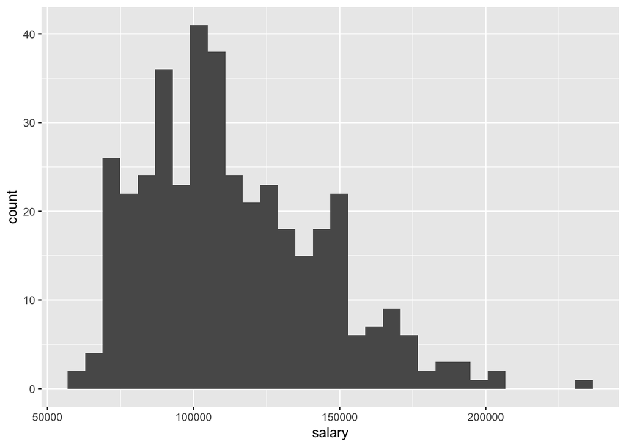

```r
ggplot(data=Salaries) + geom_histogram(aes(x=salary))
```

You could also view a smoothed version of the distribution with a density plot

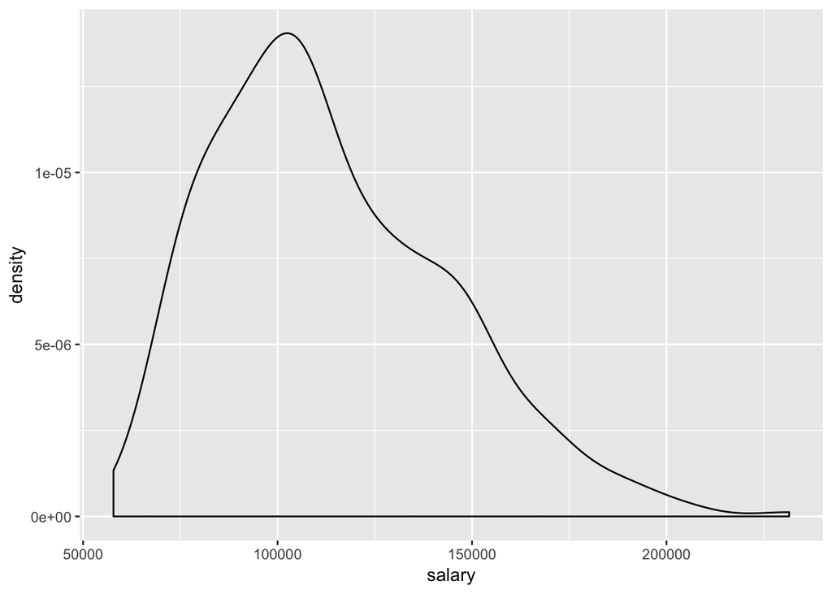

```r
ggplot(data=Salaries) + geom_density(aes(x=salary))
```

If you have categorical data, a barchart is more appropriate.

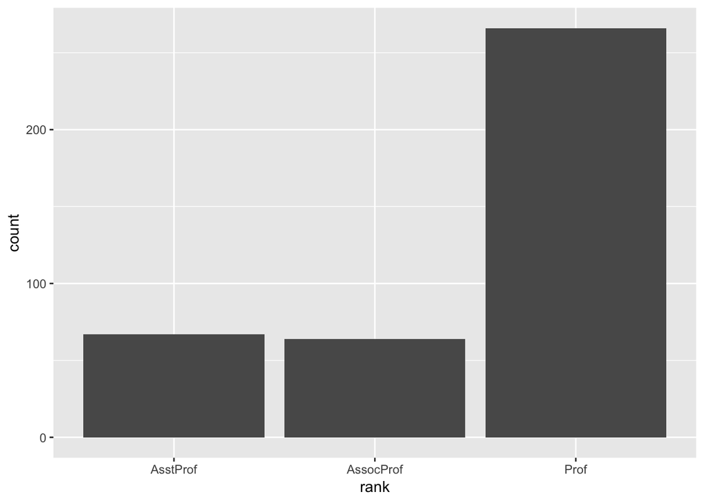

```r
ggplot(data=Salaries) + geom_bar(aes(x=rank))
```

Notice that all these plots use the same syntax: `ggplot(data=NameOfData) + geom_[something](aes(x=VariableName))`

`geom`s are short for geometric object, and include `geom_histogram()`, `geom_density()` or `geom_bar()`. There are many other ways to write `ggplot2` code, but we won’t think about those for now.

### An aside– RMarkdown

This lab (and all the rest of them) is written in RMarkdown. That means I type text, code, and formatting into a document with the file extension .Rmd.

I will make lab files available on Canvas going forward, although this one should have been pre-loaded in RStudio.

Once I have things typed into my .Rmd file, I click the “Knit” button to knit a formatted HMTL version of the lab. If you are doing this on your own machine and the knit button isn’t showing, check this [RMarkdown troubleshooting page](https://smithcollege-sds.github.io/sds-public/rmarkdown_problems.html). When I write the labs, I use the option `eval=FALSE`, which means that the output of the code doesn’t show up in my knitted document. For your homework, you need to use the option `eval=TRUE` so that the output shows up in your HTML. If you are working through this lab on your own computer, go to the top of the document and change this option. Then try re-knitting. See how all the plots and output show up in the document?

For homework, you need to submit the knitted HTML document. So, it is important to make sure your document has knitted correctly. Again, the [RMarkdown troubleshooting page](https://smithcollege-sds.github.io/sds-public/rmarkdown_problems.html) has some hints for how to do this. I usually just open it in my web browser to check it looks right.

### Multiple-variable plots in ggplot2

For two quantitative variables, a scatterplot is appropriate.

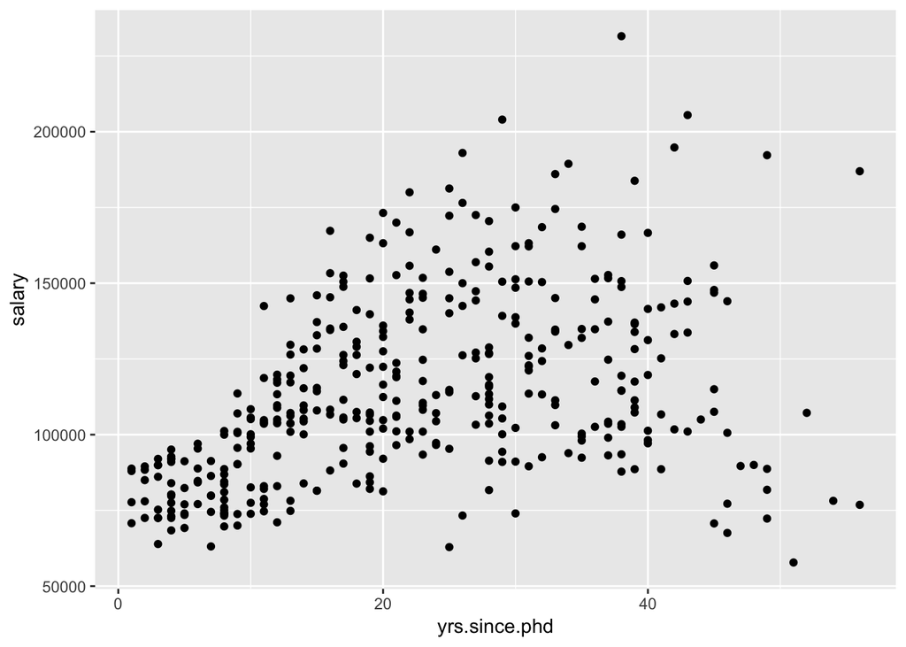

```r
ggplot(Salaries) + geom_point(aes(x=yrs.since.phd, y=salary))
```

For one quantitative and one categorical variable, you can make side-by-side boxplots

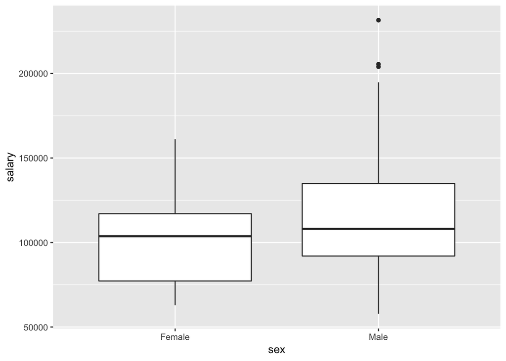

```r
ggplot(Salaries) + geom_boxplot(aes(x=sex, y=salary))
```

For two categorical variables, a things get tricker. We might want to `facet` a plot so we could compare across groups.

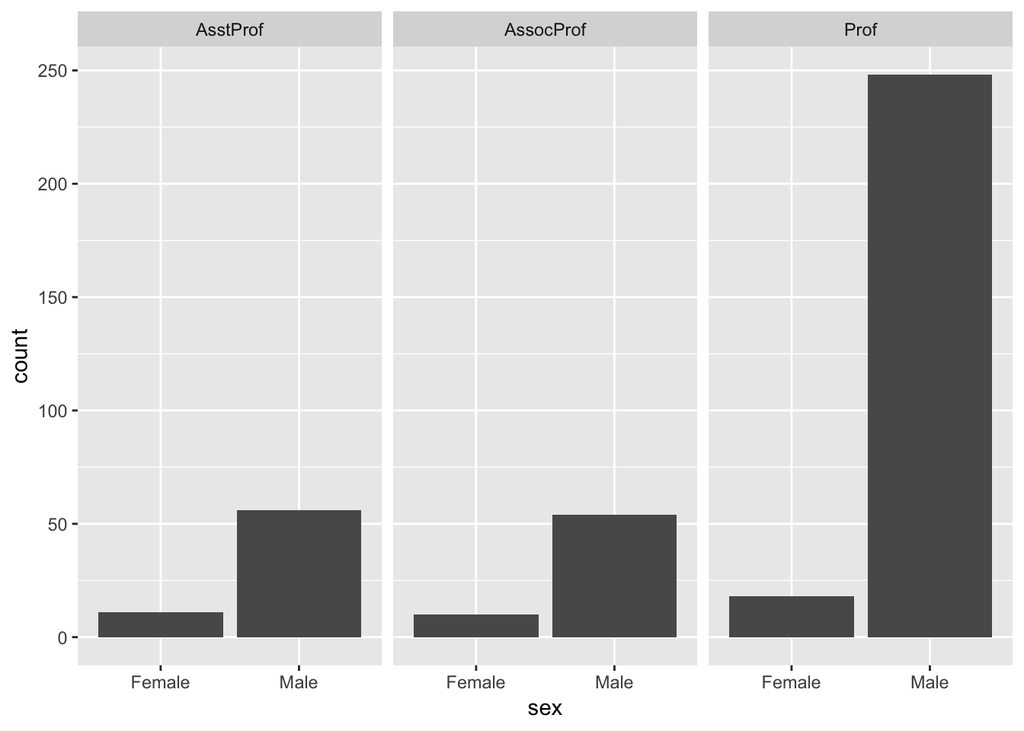

```r
ggplot(Salaries) + geom_bar(aes(x=sex)) + facet_wrap(~rank)
```

### Bells and Whistles

Most R plotting function can take many arguments that will modify their behavior. Read the documentation for more information.

```r
help(ggplot)
?geom_histogram
```

### Summary statistics

Again, there are several possible syntaxes for summary statistics. We’ll mostly use the tidyverse syntax, which looks like this:

```r
Salaries %>%
  summarize(mean(salary), sd(salary))
```

```
##   mean(salary) sd(salary)
## 1     113706.5   30289.04
```

Of course, you can see all this and more in the skim,

```r
skim(Salaries)
```

```
## Skim summary statistics
##  n obs: 397
##  n variables: 6
##
## ── Variable type:factor ───────────────────────────────────────────────────
##    variable missing complete   n n_unique
##  discipline       0      397 397        2
##        rank       0      397 397        3
##         sex       0      397 397        2
##                         top_counts ordered
##              B: 216, A: 181, NA: 0   FALSE
##  Pro: 266, Ass: 67, Ass: 64, NA: 0   FALSE
##           Mal: 358, Fem: 39, NA: 0   FALSE
##
## ── Variable type:integer ──────────────────────────────────────────────────
##       variable missing complete   n      mean       sd    p0   p25    p50
##         salary       0      397 397 113706.46 30289.04 57800 91000 107300
##    yrs.service       0      397 397     17.61    13.01     0     7     16
##  yrs.since.phd       0      397 397     22.31    12.89     1    12     21
##     p75   p100     hist
##  134185 231545 ▃▇▇▅▃▂▁▁
##      27     60 ▇▆▅▅▂▂▁▁
##      32     56 ▆▇▇▇▆▅▂▁
```

### Linear models

The syntax for linear models is different than the standard tidyverse syntax, and instead is more similar to the syntax for lattice graphics. The general framework is `goal ( y ~ x , data = mydata )` We’ll use it for modeling.

Now we can start to do some modeling!

Given how the data looked in the scatterplot we saw above, it seems reasonable to **choose** a simple linear regression model. We can then **fit** it using R.

```r
mod = lm(salary ~ yrs.since.phd, data=Salaries)
```

We’re using the assignment operator to store the results of our function into a named object. I’m using the assignment operator `=`, but you can also use `<-`. As with many things, I’ll try to be consistent, but I often switch between the two.

The reason to use the assignment operator here is because we might want to do things with our model output later. If you want to skip the assignment operator, try just running `lm(salary ~ yrs.since.phd, data=Salaries)` in your console to see what happens.

Now, we want to move on to assessing and using our model. Typically, this means we want to look at the model output (the fitted coefficients, etc). If we run `summary()` on our model object we can look at the output.

```r
summary(mod)
```

```
##
## Call:
## lm(formula = salary ~ yrs.since.phd, data = Salaries)
##
## Residuals:
##    Min     1Q Median     3Q    Max
## -84171 -19432  -2858  16086 102383
##
## Coefficients:
##               Estimate Std. Error t value Pr(>|t|)
## (Intercept)    91718.7     2765.8  33.162   <2e-16 ***
## yrs.since.phd    985.3      107.4   9.177   <2e-16 ***
## ---
## Signif. codes:  0 '***' 0.001 '**' 0.01 '*' 0.05 '.' 0.1 ' ' 1
##
## Residual standard error: 27530 on 395 degrees of freedom
## Multiple R-squared:  0.1758, Adjusted R-squared:  0.1737
## F-statistic: 84.23 on 1 and 395 DF,  p-value: < 2.2e-16
```

The p-values are quite significant, which might lead us to **assess** that the model is pretty effective. We can also **use** the model for description. To write this model out in our mathematical notation,

$$\widehat{\verb#salary#} = 91718.7 + 985.3\cdot \verb#yrs.since.phd#$$

1. What would this model **predict** for the salary of a professor who had just finished their PhD?
2. What does the model **predict** for a professor who has had their PhD for 51 years? What was the observed salary value for the person with 51 years of experience? What is the residual?

To **assess** further, we can compare it to a “null” model, where we don’t use a predictor (Instead, we just use the mean as the model for every observation).

```r
modMean = lm(salary ~ 1, data=Salaries)
summary(modMean)
```

```
##
## Call:
## lm(formula = salary ~ 1, data = Salaries)
##
## Residuals:
##    Min     1Q Median     3Q    Max
## -55906 -22706  -6406  20479 117839
##
## Coefficients:
##             Estimate Std. Error t value Pr(>|t|)
## (Intercept)   113706       1520    74.8   <2e-16 ***
## ---
## Signif. codes:  0 '***' 0.001 '**' 0.01 '*' 0.05 '.' 0.1 ' ' 1
##
## Residual standard error: 30290 on 396 degrees of freedom
```

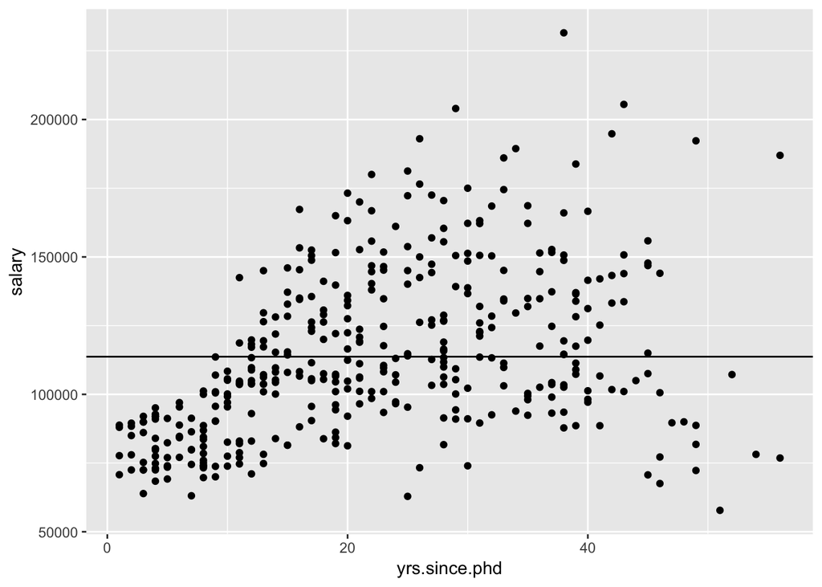

```r
p = ggplot(Salaries, aes(x=yrs.since.phd, y=salary)) + geom_point()

p + geom_abline(slope=0, intercept=113706)
```

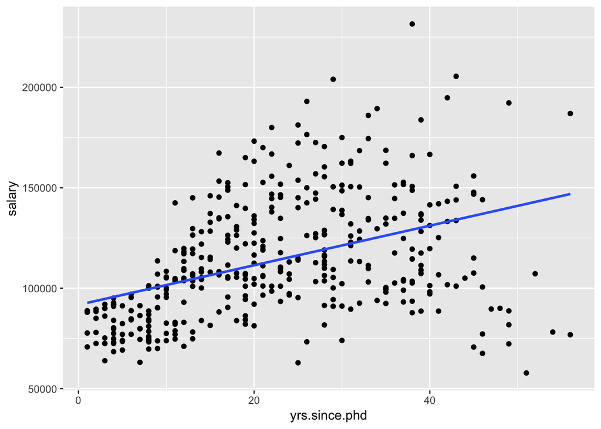

```r
p + geom_smooth(method = lm, se=FALSE)
```